# ML Pipeline Preparation

Follow the instructions below to help you create your ML pipeline.

### 1. Import libraries and load data from database.

- Import Python libraries
- Load dataset from database with [`read_sql_table`](https://pandas.pydata.org/pandas-docs/stable/generated/pandas.read_sql_table.html)
- Define feature and target variables X and Y

```python
# import libraries
import re
%matplotlib inline
import matplotlib.pyplot as plt
import nltk
nltk.download(['punkt', 'wordnet', 'stopwords'])
from nltk.corpus import stopwords
from nltk.tokenize import word_tokenize
from nltk.stem import WordNetLemmatizer
import numpy as np
import pandas as pd
import pickle
from sklearn.ensemble import RandomForestClassifier,AdaBoostClassifier
from sklearn.feature_extraction.text import CountVectorizer, TfidfTransformer
from sklearn.metrics import classification_report, accuracy_score, precision_score, recall_score, f1_score
from sklearn.model_selection import train_test_split, GridSearchCV
from sklearn.multioutput import MultiOutputClassifier
from sklearn.pipeline import Pipeline
from sklearn.tree import DecisionTreeClassifier
from sqlalchemy import create_engine
```

```python
# load data from database
engine = create_engine('sqlite:///InsertDatabaseName.db')
df = pd.read_sql_table('InsertTableName', con=engine)
categories = df.columns[4:]
X = df[['message']].values[:, 0]
y = df[categories].values
```

### 2. Write a tokenization function to process your text data

```python
# first we need to identify url_regex
url_regex = 'http[s]?://(?:[a-zA-Z]|[0-9]|[$-_@.&+]|[!*\(\),]|(?:%[0-9a-fA-F][0-9a-fA-F]))+'
def tokenize(text, lemmatizer=WordNetLemmatizer()):
    # Detecte URLs
    detected_urls = re.findall(url_regex, text)
    for url in detected_urls:
        text = text.replace(url, 'urlplaceholder')

    # Normalize&Tokenize
    tokens = nltk.word_tokenize(re.sub(r"[^a-zA-Z0-9]", " ", text.lower()))

    # Delete Stopwords
    tokens = [t for t in tokens if t not in stopwords.words('english')]

    # Lemmatize
    tokens = [lemmatizer.lemmatize(t) for t in tokens]

    return tokens
```

```python
# CheckVocabulary
vect = CountVectorizer(tokenizer=tokenize)
X_vectorized = vect.fit_transform(X)
```

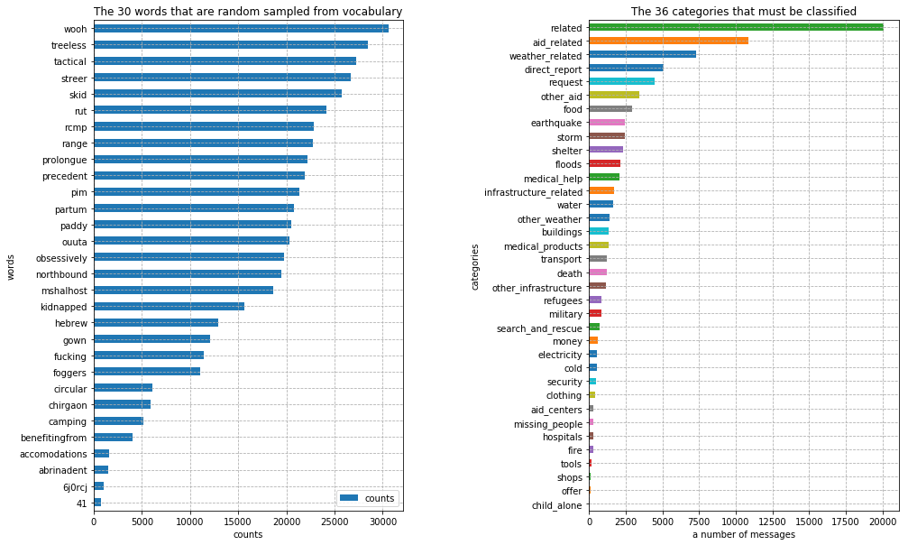

```python
# ConvertVocabularyTo pandas.dataframe
keys, values = [], []
for k, v in vect.vocabulary_.items():
    keys.append(k)
    values.append(v)

vocabulary = pd.DataFrame.from_dict({'words': keys, 'counts': values})

plt.figure(figsize=(16, 10))
plt.subplots_adjust(wspace=0.6)

ax1 = plt.subplot(1, 2, 1)
vocabulary.sample(30, random_state=72).sort_values('counts').plot.barh(x='words', y='counts', ax=ax1, colormap='tab10')
plt.title('The 30 words that are random sampled from vocabulary')
plt.xlabel('counts')
plt.grid(linestyle='dashed')

ax2 = plt.subplot(1, 2, 2)
df[categories].sum().sort_values().plot.barh(ax=ax2)
plt.title('The 36 categories that must be classified')
plt.ylabel('categories')
plt.xlabel('a number of messages')
plt.grid(linestyle='dashed')

plt.show()
```

### 3. Build a machine learning pipeline

This machine pipeline should take in the `message` column as input and output classification results on the other 36 categories in the dataset. You may find the [MultiOutputClassifier](http://scikit-learn.org/stable/modules/generated/sklearn.multioutput.MultiOutputClassifier.html) helpful for predicting multiple target variables.

```python
pipeline =  Pipeline([
    ('vect', CountVectorizer(tokenizer=tokenize)),
    ('tfidf', TfidfTransformer()),
    ('clf', MultiOutputClassifier(RandomForestClassifier(class_weight='balanced')))
])
```

### 4. Train pipeline

- Split data into train and test sets
- Train pipeline

```python
X_train, X_test, y_train, y_test = train_test_split(X,y)
pipeline.fit(X_train, y_train)
```

```
Pipeline(memory=None,
     steps=[('vect', CountVectorizer(analyzer='word', binary=False, decode_error='strict',
        dtype=<class 'numpy.int64'>, encoding='utf-8', input='content',
        lowercase=True, max_df=1.0, max_features=None, min_df=1,
        ngram_range=(1, 1), preprocessor=None, stop_words=None,
        strip...oob_score=False, random_state=None,
            verbose=0, warm_start=False),
           n_jobs=1))])
```

### 5. Test your model

Report the f1 score, precision and recall for each output category of the dataset. You can do this by iterating through the columns and calling sklearn's `classification_report` on each.

```python
def multioutput_classification_report(y_true, y_pred):
    for i in range(0, len(categories)):
        print(categories[i])
        print("\tAccuracy: {:.4f}\t\t% Precision: {:.4f}\t\t% Recall: {:.4f}\t\t% F1_score: {:.4f}".format(
            accuracy_score(y_true[:, i], y_pred[:, i]),
            precision_score(y_true[:, i], y_pred[:, i], average='weighted'),
            recall_score(y_true[:, i], y_pred[:, i], average='weighted'),
            f1_score(y_true[:, i], y_pred[:, i], average='weighted')
        ))
        #print(classification_report(y_true[:, i], y_pred[:, i]))
        #print("--------------------------------------------------")

y_pred = pipeline.predict(X_train)
multioutput_classification_report(y_train, y_pred)
```

```
related
	Accuracy: 0.9910		% Precision: 0.9910		% Recall: 0.9910		% F1_score: 0.9910
request
	Accuracy: 0.9877		% Precision: 0.9878		% Recall: 0.9877		% F1_score: 0.9875
offer
	Accuracy: 0.9987		% Precision: 0.9987		% Recall: 0.9987		% F1_score: 0.9986
aid_related
	Accuracy: 0.9859		% Precision: 0.9860		% Recall: 0.9859		% F1_score: 0.9858
medical_help
	Accuracy: 0.9881		% Precision: 0.9882		% Recall: 0.9881		% F1_score: 0.9877
medical_products
	Accuracy: 0.9923		% Precision: 0.9923		% Recall: 0.9923		% F1_score: 0.9920
search_and_rescue
	Accuracy: 0.9949		% Precision: 0.9949		% Recall: 0.9949		% F1_score: 0.9947
security
	Accuracy: 0.9948		% Precision: 0.9948		% Recall: 0.9948		% F1_score: 0.9944
military
	Accuracy: 0.9959		% Precision: 0.9959		% Recall: 0.9959		% F1_score: 0.9958
child_alone
	Accuracy: 1.0000		% Precision: 1.0000		% Recall: 1.0000		% F1_score: 1.0000
water
	Accuracy: 0.9960		% Precision: 0.9960		% Recall: 0.9960		% F1_score: 0.9959
food
	Accuracy: 0.9942		% Precision: 0.9942		% Recall: 0.9942		% F1_score: 0.9941
shelter
	Accuracy: 0.9934		% Precision: 0.9934		% Recall: 0.9934		% F1_score: 0.9933
clothing
	Accuracy: 0.9974		% Precision: 0.9974		% Recall: 0.9974		% F1_score: 0.9973
money
	Accuracy: 0.9949		% Precision: 0.9949		% Recall: 0.9949		% F1_score: 0.9946
missing_people
	Accuracy: 0.9977		% Precision: 0.9977		% Recall: 0.9977		% F1_score: 0.9975
refugees
	Accuracy: 0.9936		% Precision: 0.9936		% Recall: 0.9936		% F1_score: 0.9933
death
	Accuracy: 0.9952		% Precision: 0.9952		% Recall: 0.9952		% F1_score: 0.9950
other_aid
	Accuracy: 0.9799		% Precision: 0.9801		% Recall: 0.9799		% F1_score: 0.9793
infrastructure_related
	Accuracy: 0.9862		% Precision: 0.9862		% Recall: 0.9862		% F1_score: 0.9855
```

[output cut: 17 more lines]

```
	Accuracy: 0.9888		% Precision: 0.9889		% Recall: 0.9888		% F1_score: 0.9888
floods
	Accuracy: 0.9922		% Precision: 0.9923		% Recall: 0.9922		% F1_score: 0.9920
storm
	Accuracy: 0.9926		% Precision: 0.9926		% Recall: 0.9926		% F1_score: 0.9925
fire
	Accuracy: 0.9974		% Precision: 0.9974		% Recall: 0.9974		% F1_score: 0.9972
earthquake
	Accuracy: 0.9957		% Precision: 0.9957		% Recall: 0.9957		% F1_score: 0.9956
cold
	Accuracy: 0.9967		% Precision: 0.9967		% Recall: 0.9967		% F1_score: 0.9966
other_weather
	Accuracy: 0.9892		% Precision: 0.9892		% Recall: 0.9892		% F1_score: 0.9886
direct_report
	Accuracy: 0.9845		% Precision: 0.9846		% Recall: 0.9845		% F1_score: 0.9843
```

```python
y_pred = pipeline.predict(X_test)

multioutput_classification_report(y_test, y_pred)
```

```
related
	Accuracy: 0.8187		% Precision: 0.8093		% Recall: 0.8187		% F1_score: 0.8124
request
	Accuracy: 0.8839		% Precision: 0.8750		% Recall: 0.8839		% F1_score: 0.8727
offer
	Accuracy: 0.9950		% Precision: 0.9900		% Recall: 0.9950		% F1_score: 0.9925
aid_related
	Accuracy: 0.7540		% Precision: 0.7523		% Recall: 0.7540		% F1_score: 0.7496
medical_help
	Accuracy: 0.9220		% Precision: 0.8931		% Recall: 0.9220		% F1_score: 0.8953
medical_products
	Accuracy: 0.9512		% Precision: 0.9364		% Recall: 0.9512		% F1_score: 0.9317
search_and_rescue
	Accuracy: 0.9742		% Precision: 0.9707		% Recall: 0.9742		% F1_score: 0.9631
security
	Accuracy: 0.9837		% Precision: 0.9682		% Recall: 0.9837		% F1_score: 0.9759
military
	Accuracy: 0.9666		% Precision: 0.9532		% Recall: 0.9666		% F1_score: 0.9535
child_alone
	Accuracy: 1.0000		% Precision: 1.0000		% Recall: 1.0000		% F1_score: 1.0000
water
	Accuracy: 0.9539		% Precision: 0.9483		% Recall: 0.9539		% F1_score: 0.9461
food
	Accuracy: 0.9359		% Precision: 0.9312		% Recall: 0.9359		% F1_score: 0.9295
shelter
	Accuracy: 0.9294		% Precision: 0.9197		% Recall: 0.9294		% F1_score: 0.9144
clothing
	Accuracy: 0.9870		% Precision: 0.9828		% Recall: 0.9870		% F1_score: 0.9823
money
	Accuracy: 0.9792		% Precision: 0.9797		% Recall: 0.9792		% F1_score: 0.9697
missing_people
	Accuracy: 0.9892		% Precision: 0.9864		% Recall: 0.9892		% F1_score: 0.9847
refugees
	Accuracy: 0.9683		% Precision: 0.9570		% Recall: 0.9683		% F1_score: 0.9541
death
	Accuracy: 0.9571		% Precision: 0.9493		% Recall: 0.9571		% F1_score: 0.9401
other_aid
	Accuracy: 0.8718		% Precision: 0.8334		% Recall: 0.8718		% F1_score: 0.8336
infrastructure_related
	Accuracy: 0.9339		% Precision: 0.8884		% Recall: 0.9339		% F1_score: 0.9034
```

[output cut: 17 more lines]

```
	Accuracy: 0.8522		% Precision: 0.8489		% Recall: 0.8522		% F1_score: 0.8441
floods
	Accuracy: 0.9329		% Precision: 0.9273		% Recall: 0.9329		% F1_score: 0.9135
storm
	Accuracy: 0.9248		% Precision: 0.9137		% Recall: 0.9248		% F1_score: 0.9112
fire
	Accuracy: 0.9876		% Precision: 0.9754		% Recall: 0.9876		% F1_score: 0.9815
earthquake
	Accuracy: 0.9535		% Precision: 0.9515		% Recall: 0.9535		% F1_score: 0.9484
cold
	Accuracy: 0.9783		% Precision: 0.9684		% Recall: 0.9783		% F1_score: 0.9685
other_weather
	Accuracy: 0.9504		% Precision: 0.9205		% Recall: 0.9504		% F1_score: 0.9271
direct_report
	Accuracy: 0.8477		% Precision: 0.8330		% Recall: 0.8477		% F1_score: 0.8299
```

### 6. Improve your model

Use grid search to find better parameters.

```python
parameters = {
    'clf__estimator__n_estimators': [20, 50]
}

cv = GridSearchCV(estimator=pipeline, param_grid=parameters, cv=3, scoring='f1_weighted', verbose=3)

cv.fit(X_train, y_train)
```

```
Fitting 3 folds for each of 2 candidates, totalling 6 fits
[CV] clf__estimator__n_estimators=20 .................................
```

```
[CV]  clf__estimator__n_estimators=20, score=0.5403946028020987, total= 2.7min
[CV] clf__estimator__n_estimators=20 .................................
```

```
[Parallel(n_jobs=1)]: Done   1 out of   1 | elapsed:  3.8min remaining:    0.0s
```

```
[CV]  clf__estimator__n_estimators=20, score=0.5368735018704847, total= 2.7min
[CV] clf__estimator__n_estimators=20 .................................
```

```
[Parallel(n_jobs=1)]: Done   2 out of   2 | elapsed:  7.6min remaining:    0.0s
```

```
[CV]  clf__estimator__n_estimators=20, score=0.5406417435159623, total= 2.7min
[CV] clf__estimator__n_estimators=50 .................................
```

```
[CV]  clf__estimator__n_estimators=50, score=0.5522050783117041, total= 4.5min
[CV] clf__estimator__n_estimators=50 .................................
```

```
[CV]  clf__estimator__n_estimators=50, score=0.5513597388837754, total= 4.5min
[CV] clf__estimator__n_estimators=50 .................................
```

```
[CV]  clf__estimator__n_estimators=50, score=0.549939822919701, total= 4.5min
```

```
[Parallel(n_jobs=1)]: Done   6 out of   6 | elapsed: 28.5min finished
```

```
GridSearchCV(cv=3, error_score='raise',
       estimator=Pipeline(memory=None,
     steps=[('vect', CountVectorizer(analyzer='word', binary=False, decode_error='strict',
        dtype=<class 'numpy.int64'>, encoding='utf-8', input='content',
        lowercase=True, max_df=1.0, max_features=None, min_df=1,
        ngram_range=(1, 1), preprocessor=None, stop_words=None,
        strip...oob_score=False, random_state=None,
            verbose=0, warm_start=False),
           n_jobs=1))]),
       fit_params=None, iid=True, n_jobs=1,
       param_grid={'clf__estimator__n_estimators': [20, 50]},
       pre_dispatch='2*n_jobs', refit=True, return_train_score='warn',
       scoring='f1_weighted', verbose=3)
```

### 7. Test your model

Show the accuracy, precision, and recall of the tuned model.

Since this project focuses on code quality, process, and pipelines, there is no minimum performance metric needed to pass. However, make sure to fine tune your models for accuracy, precision and recall to make your project stand out - especially for your portfolio!

```python
y_pred = cv.predict(X_train)
multioutput_classification_report(y_train, y_pred)
```

```
related
	Accuracy: 0.9980		% Precision: 0.9980		% Recall: 0.9980		% F1_score: 0.9980
request
	Accuracy: 0.9987		% Precision: 0.9987		% Recall: 0.9987		% F1_score: 0.9987
offer
	Accuracy: 0.9998		% Precision: 0.9998		% Recall: 0.9998		% F1_score: 0.9998
aid_related
	Accuracy: 0.9986		% Precision: 0.9986		% Recall: 0.9986		% F1_score: 0.9986
medical_help
	Accuracy: 0.9989		% Precision: 0.9989		% Recall: 0.9989		% F1_score: 0.9989
medical_products
	Accuracy: 0.9995		% Precision: 0.9995		% Recall: 0.9995		% F1_score: 0.9995
search_and_rescue
	Accuracy: 0.9992		% Precision: 0.9992		% Recall: 0.9992		% F1_score: 0.9992
security
	Accuracy: 0.9991		% Precision: 0.9991		% Recall: 0.9991		% F1_score: 0.9991
military
	Accuracy: 0.9996		% Precision: 0.9996		% Recall: 0.9996		% F1_score: 0.9996
child_alone
	Accuracy: 1.0000		% Precision: 1.0000		% Recall: 1.0000		% F1_score: 1.0000
water
	Accuracy: 0.9997		% Precision: 0.9997		% Recall: 0.9997		% F1_score: 0.9997
food
	Accuracy: 0.9998		% Precision: 0.9998		% Recall: 0.9998		% F1_score: 0.9998
shelter
	Accuracy: 0.9996		% Precision: 0.9996		% Recall: 0.9996		% F1_score: 0.9996
clothing
	Accuracy: 0.9998		% Precision: 0.9998		% Recall: 0.9998		% F1_score: 0.9998
money
	Accuracy: 0.9997		% Precision: 0.9997		% Recall: 0.9997		% F1_score: 0.9997
missing_people
	Accuracy: 0.9998		% Precision: 0.9998		% Recall: 0.9998		% F1_score: 0.9998
refugees
	Accuracy: 0.9992		% Precision: 0.9992		% Recall: 0.9992		% F1_score: 0.9992
death
	Accuracy: 0.9998		% Precision: 0.9998		% Recall: 0.9998		% F1_score: 0.9998
other_aid
	Accuracy: 0.9981		% Precision: 0.9981		% Recall: 0.9981		% F1_score: 0.9981
infrastructure_related
	Accuracy: 0.9986		% Precision: 0.9986		% Recall: 0.9986		% F1_score: 0.9986
```

[output cut: 17 more lines]

```
	Accuracy: 0.9991		% Precision: 0.9991		% Recall: 0.9991		% F1_score: 0.9991
floods
	Accuracy: 0.9992		% Precision: 0.9992		% Recall: 0.9992		% F1_score: 0.9992
storm
	Accuracy: 0.9997		% Precision: 0.9997		% Recall: 0.9997		% F1_score: 0.9997
fire
	Accuracy: 0.9999		% Precision: 0.9999		% Recall: 0.9999		% F1_score: 0.9999
earthquake
	Accuracy: 0.9993		% Precision: 0.9993		% Recall: 0.9993		% F1_score: 0.9993
cold
	Accuracy: 0.9996		% Precision: 0.9996		% Recall: 0.9996		% F1_score: 0.9996
other_weather
	Accuracy: 0.9992		% Precision: 0.9992		% Recall: 0.9992		% F1_score: 0.9992
direct_report
	Accuracy: 0.9983		% Precision: 0.9983		% Recall: 0.9983		% F1_score: 0.9983
```

```python
y_pred = cv.predict(X_test)
multioutput_classification_report(y_test, y_pred)
```

```
related
	Accuracy: 0.8306		% Precision: 0.8190		% Recall: 0.8306		% F1_score: 0.8196
request
	Accuracy: 0.8924		% Precision: 0.8855		% Recall: 0.8924		% F1_score: 0.8828
offer
	Accuracy: 0.9950		% Precision: 0.9900		% Recall: 0.9950		% F1_score: 0.9925
aid_related
	Accuracy: 0.7748		% Precision: 0.7735		% Recall: 0.7748		% F1_score: 0.7738
medical_help
	Accuracy: 0.9251		% Precision: 0.9059		% Recall: 0.9251		% F1_score: 0.8965
medical_products
	Accuracy: 0.9530		% Precision: 0.9458		% Recall: 0.9530		% F1_score: 0.9345
search_and_rescue
	Accuracy: 0.9731		% Precision: 0.9650		% Recall: 0.9731		% F1_score: 0.9603
security
	Accuracy: 0.9840		% Precision: 0.9764		% Recall: 0.9840		% F1_score: 0.9763
military
	Accuracy: 0.9669		% Precision: 0.9550		% Recall: 0.9669		% F1_score: 0.9532
child_alone
	Accuracy: 1.0000		% Precision: 1.0000		% Recall: 1.0000		% F1_score: 1.0000
water
	Accuracy: 0.9539		% Precision: 0.9489		% Recall: 0.9539		% F1_score: 0.9453
food
	Accuracy: 0.9434		% Precision: 0.9398		% Recall: 0.9434		% F1_score: 0.9392
shelter
	Accuracy: 0.9350		% Precision: 0.9297		% Recall: 0.9350		% F1_score: 0.9214
clothing
	Accuracy: 0.9872		% Precision: 0.9833		% Recall: 0.9872		% F1_score: 0.9826
money
	Accuracy: 0.9794		% Precision: 0.9773		% Recall: 0.9794		% F1_score: 0.9703
missing_people
	Accuracy: 0.9889		% Precision: 0.9854		% Recall: 0.9889		% F1_score: 0.9838
refugees
	Accuracy: 0.9681		% Precision: 0.9566		% Recall: 0.9681		% F1_score: 0.9532
death
	Accuracy: 0.9574		% Precision: 0.9518		% Recall: 0.9574		% F1_score: 0.9403
other_aid
	Accuracy: 0.8721		% Precision: 0.8306		% Recall: 0.8721		% F1_score: 0.8234
infrastructure_related
	Accuracy: 0.9341		% Precision: 0.8846		% Recall: 0.9341		% F1_score: 0.9031
```

[output cut: 17 more lines]

```
	Accuracy: 0.8847		% Precision: 0.8825		% Recall: 0.8847		% F1_score: 0.8811
floods
	Accuracy: 0.9411		% Precision: 0.9379		% Recall: 0.9411		% F1_score: 0.9278
storm
	Accuracy: 0.9336		% Precision: 0.9264		% Recall: 0.9336		% F1_score: 0.9237
fire
	Accuracy: 0.9875		% Precision: 0.9754		% Recall: 0.9875		% F1_score: 0.9814
earthquake
	Accuracy: 0.9608		% Precision: 0.9591		% Recall: 0.9608		% F1_score: 0.9578
cold
	Accuracy: 0.9782		% Precision: 0.9668		% Recall: 0.9782		% F1_score: 0.9684
other_weather
	Accuracy: 0.9507		% Precision: 0.9288		% Recall: 0.9507		% F1_score: 0.9273
direct_report
	Accuracy: 0.8552		% Precision: 0.8429		% Recall: 0.8552		% F1_score: 0.8393
```

### 8. Try improving your model further. Here are a few ideas:

- try other machine learning algorithms
- add other features besides the TF-IDF

```python
pipeline_ada = Pipeline([
    ('vect', CountVectorizer(tokenizer=tokenize)),
    ('tfidf', TfidfTransformer()),
    ('clf', MultiOutputClassifier(
        AdaBoostClassifier(base_estimator=DecisionTreeClassifier(max_depth=1, class_weight='balanced'))
    ))
])

parameters_ada = {
    'clf__estimator__learning_rate': [0.1, 0.3],
    'clf__estimator__n_estimators': [100, 200]
}

cv_ada = GridSearchCV(estimator=pipeline_ada, param_grid=parameters_ada, cv=3, scoring='f1_weighted', verbose=3)
cv_ada.fit(X_train, y_train)
```

```
Fitting 3 folds for each of 4 candidates, totalling 12 fits
[CV] clf__estimator__learning_rate=0.1, clf__estimator__n_estimators=100
```

```
[CV]  clf__estimator__learning_rate=0.1, clf__estimator__n_estimators=100, score=0.6075616277445776, total= 3.7min
[CV] clf__estimator__learning_rate=0.1, clf__estimator__n_estimators=100
```

```
[Parallel(n_jobs=1)]: Done   1 out of   1 | elapsed:  4.9min remaining:    0.0s
```

```
[CV]  clf__estimator__learning_rate=0.1, clf__estimator__n_estimators=100, score=0.6042763461813516, total= 3.9min
[CV] clf__estimator__learning_rate=0.1, clf__estimator__n_estimators=100
```

```
[Parallel(n_jobs=1)]: Done   2 out of   2 | elapsed:  9.9min remaining:    0.0s
```

```
[CV]  clf__estimator__learning_rate=0.1, clf__estimator__n_estimators=100, score=0.6094467280777751, total= 3.8min
[CV] clf__estimator__learning_rate=0.1, clf__estimator__n_estimators=200
```

```
[CV]  clf__estimator__learning_rate=0.1, clf__estimator__n_estimators=200, score=0.6214148549808756, total= 6.2min
[CV] clf__estimator__learning_rate=0.1, clf__estimator__n_estimators=200
```

```
[CV]  clf__estimator__learning_rate=0.1, clf__estimator__n_estimators=200, score=0.6201254397979571, total= 6.3min
[CV] clf__estimator__learning_rate=0.1, clf__estimator__n_estimators=200
```

```
[CV]  clf__estimator__learning_rate=0.1, clf__estimator__n_estimators=200, score=0.6215258028512515, total= 6.1min
[CV] clf__estimator__learning_rate=0.3, clf__estimator__n_estimators=100
```

```
[CV]  clf__estimator__learning_rate=0.3, clf__estimator__n_estimators=100, score=0.6290108017446661, total= 3.9min
[CV] clf__estimator__learning_rate=0.3, clf__estimator__n_estimators=100
```

```
[CV]  clf__estimator__learning_rate=0.3, clf__estimator__n_estimators=100, score=0.62464472458894, total= 3.9min
[CV] clf__estimator__learning_rate=0.3, clf__estimator__n_estimators=100
```

```
[CV]  clf__estimator__learning_rate=0.3, clf__estimator__n_estimators=100, score=0.6262951494085117, total= 3.8min
[CV] clf__estimator__learning_rate=0.3, clf__estimator__n_estimators=200
```

```
[CV]  clf__estimator__learning_rate=0.3, clf__estimator__n_estimators=200, score=0.6339052357382939, total= 6.2min
[CV] clf__estimator__learning_rate=0.3, clf__estimator__n_estimators=200
```

```
[CV]  clf__estimator__learning_rate=0.3, clf__estimator__n_estimators=200, score=0.632308250873504, total= 6.2min
[CV] clf__estimator__learning_rate=0.3, clf__estimator__n_estimators=200
```

```
[CV]  clf__estimator__learning_rate=0.3, clf__estimator__n_estimators=200, score=0.6328610057424363, total= 6.1min
```

```
[Parallel(n_jobs=1)]: Done  12 out of  12 | elapsed: 74.6min finished
```

```
GridSearchCV(cv=3, error_score='raise',
       estimator=Pipeline(memory=None,
     steps=[('vect', CountVectorizer(analyzer='word', binary=False, decode_error='strict',
        dtype=<class 'numpy.int64'>, encoding='utf-8', input='content',
        lowercase=True, max_df=1.0, max_features=None, min_df=1,
        ngram_range=(1, 1), preprocessor=None, stop_words=None,
        strip...er='best'),
          learning_rate=1.0, n_estimators=50, random_state=None),
           n_jobs=1))]),
       fit_params=None, iid=True, n_jobs=1,
       param_grid={'clf__estimator__learning_rate': [0.1, 0.3], 'clf__estimator__n_estimators': [100, 200]},
       pre_dispatch='2*n_jobs', refit=True, return_train_score='warn',
       scoring='f1_weighted', verbose=3)
```

```python
# what is the best parameters set?
cv_ada.best_params_
```

```
{'clf__estimator__learning_rate': 0.3, 'clf__estimator__n_estimators': 200}
```

```python
y_pred = cv_ada.predict(X_train)
multioutput_classification_report(y_train, y_pred)
```

```
related
	Accuracy: 0.7372		% Precision: 0.8365		% Recall: 0.7372		% F1_score: 0.7569
request
	Accuracy: 0.8685		% Precision: 0.8886		% Recall: 0.8685		% F1_score: 0.8754
offer
	Accuracy: 0.9656		% Precision: 0.9962		% Recall: 0.9656		% F1_score: 0.9791
aid_related
	Accuracy: 0.7825		% Precision: 0.7814		% Recall: 0.7825		% F1_score: 0.7816
medical_help
	Accuracy: 0.9006		% Precision: 0.9308		% Recall: 0.9006		% F1_score: 0.9118
medical_products
	Accuracy: 0.9069		% Precision: 0.9541		% Recall: 0.9069		% F1_score: 0.9244
search_and_rescue
	Accuracy: 0.8676		% Precision: 0.9714		% Recall: 0.8676		% F1_score: 0.9087
security
	Accuracy: 0.8871		% Precision: 0.9810		% Recall: 0.8871		% F1_score: 0.9258
military
	Accuracy: 0.9586		% Precision: 0.9782		% Recall: 0.9586		% F1_score: 0.9654
child_alone
	Accuracy: 1.0000		% Precision: 1.0000		% Recall: 1.0000		% F1_score: 1.0000
water
	Accuracy: 0.9514		% Precision: 0.9661		% Recall: 0.9514		% F1_score: 0.9562
food
	Accuracy: 0.9531		% Precision: 0.9570		% Recall: 0.9531		% F1_score: 0.9545
shelter
	Accuracy: 0.9344		% Precision: 0.9480		% Recall: 0.9344		% F1_score: 0.9392
clothing
	Accuracy: 0.9779		% Precision: 0.9889		% Recall: 0.9779		% F1_score: 0.9819
money
	Accuracy: 0.9477		% Precision: 0.9806		% Recall: 0.9477		% F1_score: 0.9601
missing_people
	Accuracy: 0.9450		% Precision: 0.9897		% Recall: 0.9450		% F1_score: 0.9635
refugees
	Accuracy: 0.9254		% Precision: 0.9688		% Recall: 0.9254		% F1_score: 0.9419
death
	Accuracy: 0.9515		% Precision: 0.9687		% Recall: 0.9515		% F1_score: 0.9576
other_aid
	Accuracy: 0.7909		% Precision: 0.8618		% Recall: 0.7909		% F1_score: 0.8156
infrastructure_related
	Accuracy: 0.8081		% Precision: 0.9293		% Recall: 0.8081		% F1_score: 0.8520
```

[output cut: 17 more lines]

```
	Accuracy: 0.8913		% Precision: 0.8896		% Recall: 0.8913		% F1_score: 0.8900
floods
	Accuracy: 0.9454		% Precision: 0.9501		% Recall: 0.9454		% F1_score: 0.9474
storm
	Accuracy: 0.9482		% Precision: 0.9571		% Recall: 0.9482		% F1_score: 0.9512
fire
	Accuracy: 0.9753		% Precision: 0.9919		% Recall: 0.9753		% F1_score: 0.9817
earthquake
	Accuracy: 0.9738		% Precision: 0.9740		% Recall: 0.9738		% F1_score: 0.9738
cold
	Accuracy: 0.9664		% Precision: 0.9847		% Recall: 0.9664		% F1_score: 0.9732
other_weather
	Accuracy: 0.8769		% Precision: 0.9461		% Recall: 0.8769		% F1_score: 0.9028
direct_report
	Accuracy: 0.8176		% Precision: 0.8488		% Recall: 0.8176		% F1_score: 0.8281
```

```python
y_pred = cv_ada.predict(X_test)
multioutput_classification_report(y_test, y_pred)
```

```
related
	Accuracy: 0.7298		% Precision: 0.8267		% Recall: 0.7298		% F1_score: 0.7506
request
	Accuracy: 0.8489		% Precision: 0.8725		% Recall: 0.8489		% F1_score: 0.8573
offer
	Accuracy: 0.9515		% Precision: 0.9906		% Recall: 0.9515		% F1_score: 0.9704
aid_related
	Accuracy: 0.7658		% Precision: 0.7652		% Recall: 0.7658		% F1_score: 0.7655
medical_help
	Accuracy: 0.8866		% Precision: 0.9184		% Recall: 0.8866		% F1_score: 0.8993
medical_products
	Accuracy: 0.8927		% Precision: 0.9413		% Recall: 0.8927		% F1_score: 0.9123
search_and_rescue
	Accuracy: 0.8515		% Precision: 0.9607		% Recall: 0.8515		% F1_score: 0.8981
security
	Accuracy: 0.8760		% Precision: 0.9728		% Recall: 0.8760		% F1_score: 0.9198
military
	Accuracy: 0.9530		% Precision: 0.9702		% Recall: 0.9530		% F1_score: 0.9597
child_alone
	Accuracy: 1.0000		% Precision: 1.0000		% Recall: 1.0000		% F1_score: 1.0000
water
	Accuracy: 0.9454		% Precision: 0.9633		% Recall: 0.9454		% F1_score: 0.9513
food
	Accuracy: 0.9484		% Precision: 0.9528		% Recall: 0.9484		% F1_score: 0.9501
shelter
	Accuracy: 0.9300		% Precision: 0.9464		% Recall: 0.9300		% F1_score: 0.9357
clothing
	Accuracy: 0.9730		% Precision: 0.9863		% Recall: 0.9730		% F1_score: 0.9784
money
	Accuracy: 0.9431		% Precision: 0.9776		% Recall: 0.9431		% F1_score: 0.9571
missing_people
	Accuracy: 0.9268		% Precision: 0.9812		% Recall: 0.9268		% F1_score: 0.9520
refugees
	Accuracy: 0.9086		% Precision: 0.9609		% Recall: 0.9086		% F1_score: 0.9302
death
	Accuracy: 0.9417		% Precision: 0.9620		% Recall: 0.9417		% F1_score: 0.9494
other_aid
	Accuracy: 0.7695		% Precision: 0.8456		% Recall: 0.7695		% F1_score: 0.7977
infrastructure_related
	Accuracy: 0.7930		% Precision: 0.9159		% Recall: 0.7930		% F1_score: 0.8399
```

[output cut: 17 more lines]

```
	Accuracy: 0.8908		% Precision: 0.8894		% Recall: 0.8908		% F1_score: 0.8899
floods
	Accuracy: 0.9376		% Precision: 0.9438		% Recall: 0.9376		% F1_score: 0.9402
storm
	Accuracy: 0.9452		% Precision: 0.9552		% Recall: 0.9452		% F1_score: 0.9486
fire
	Accuracy: 0.9655		% Precision: 0.9840		% Recall: 0.9655		% F1_score: 0.9736
earthquake
	Accuracy: 0.9724		% Precision: 0.9727		% Recall: 0.9724		% F1_score: 0.9725
cold
	Accuracy: 0.9558		% Precision: 0.9757		% Recall: 0.9558		% F1_score: 0.9641
other_weather
	Accuracy: 0.8613		% Precision: 0.9374		% Recall: 0.8613		% F1_score: 0.8920
direct_report
	Accuracy: 0.7937		% Precision: 0.8329		% Recall: 0.7937		% F1_score: 0.8069
```

### 9. Export your model as a pickle file

```python
with open('adaboost_cv.pkl', 'wb') as file:
    pickle.dump(cv_ada, file)
```

### 10. Use this notebook to complete `train.py`

Use the template file attached in the Resources folder to write a script that runs the steps above to create a database and export a model based on a new dataset specified by the user.